# error_noclim

Sara Orofino

1/9/2020

## Data

Need to compare the new error simualtions with no climate change to perfect management and perfect management given FISHE to see what HCRs work.

Read in data:

Want to graph biomass and catch over time for perfect, perfect given FISHE and error at the different HCRs to see which ones work

First let’s separate by HCRs:

## 20% Reduction

First need to get a subset that’s easier to graph. Since b0 = 1500 and r = 0.1 is probably the most likely to not do well I’ll subset for that.

Graph biomass and catch over time:

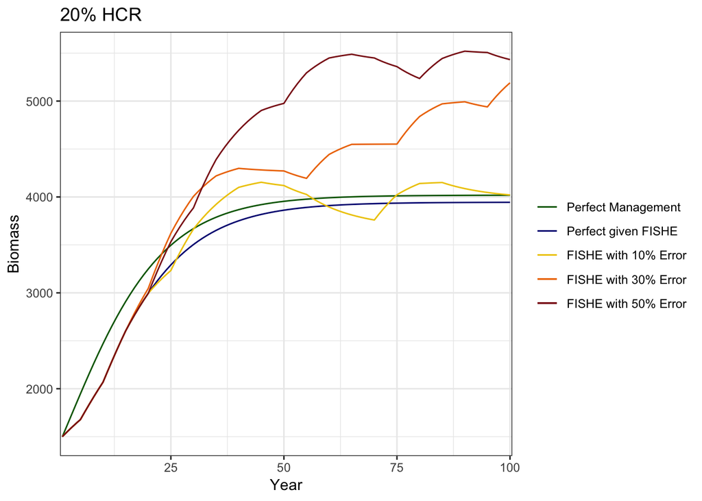

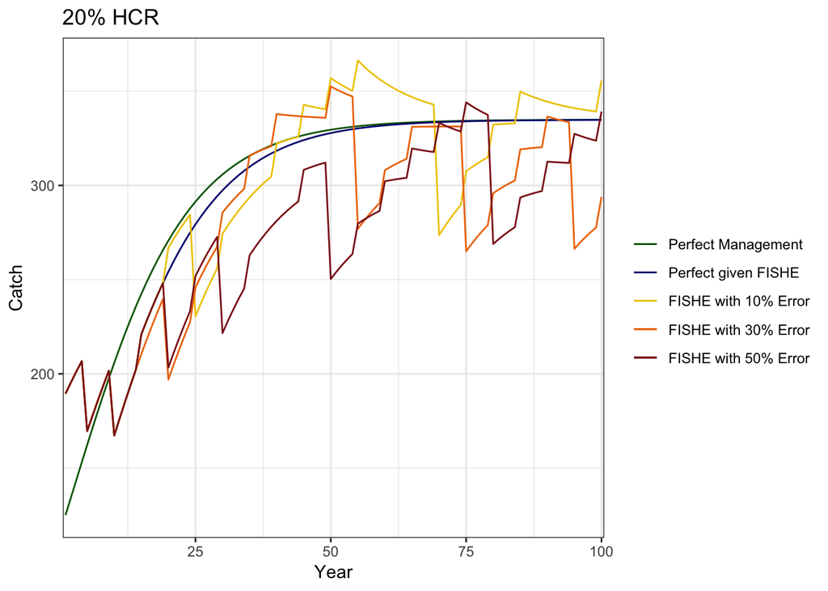

## 25% Reduction

Subset for b0 = 1500 and r = 0.1; perfect management won’t change so just need to subset for perfect given FISHE and the error tests.

Graph biomass and catch over time:

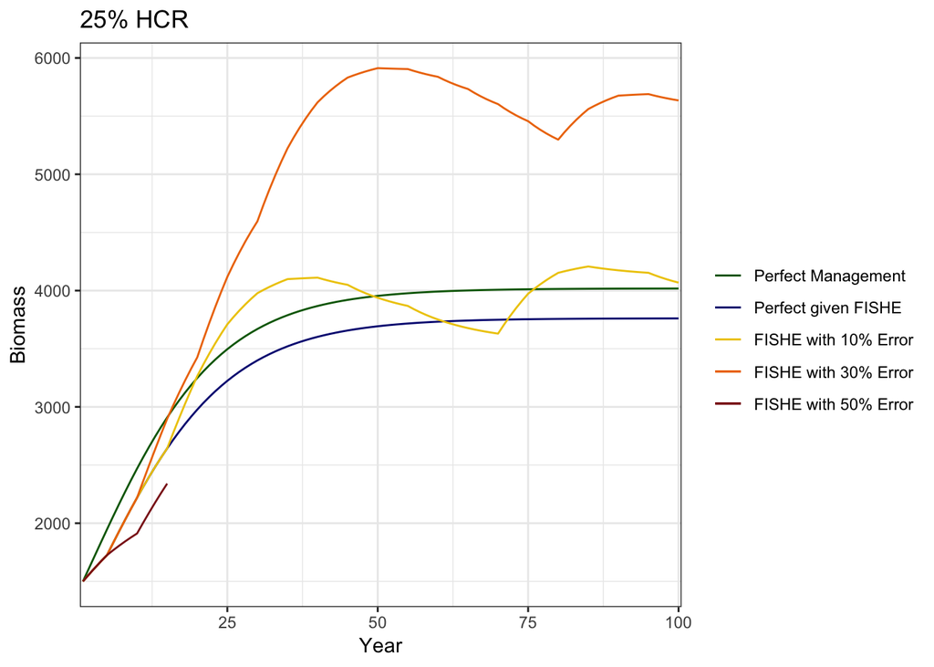

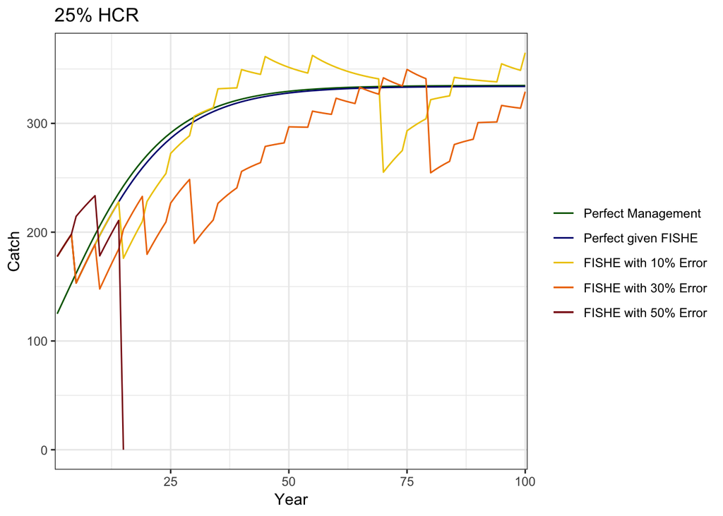

## 30% Reduction

Subset for b0 = 1500 and r = 0.1; perfect management won’t change so just need to subset for perfect given FISHE and the error tests.

Graph biomass and catch over time:

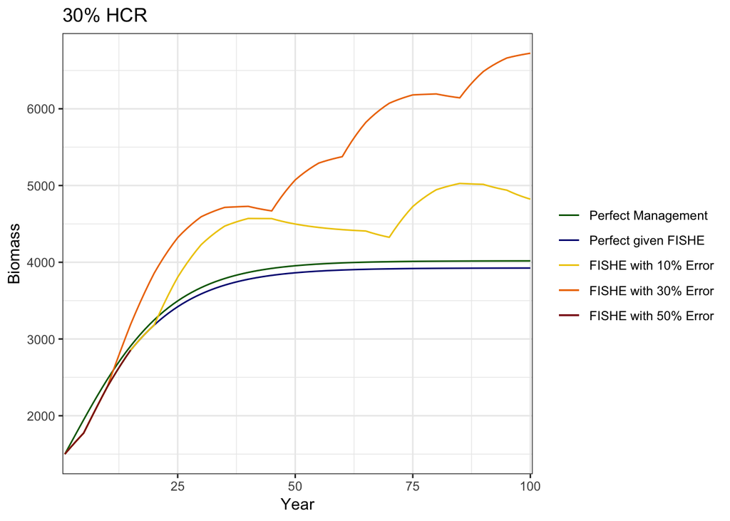

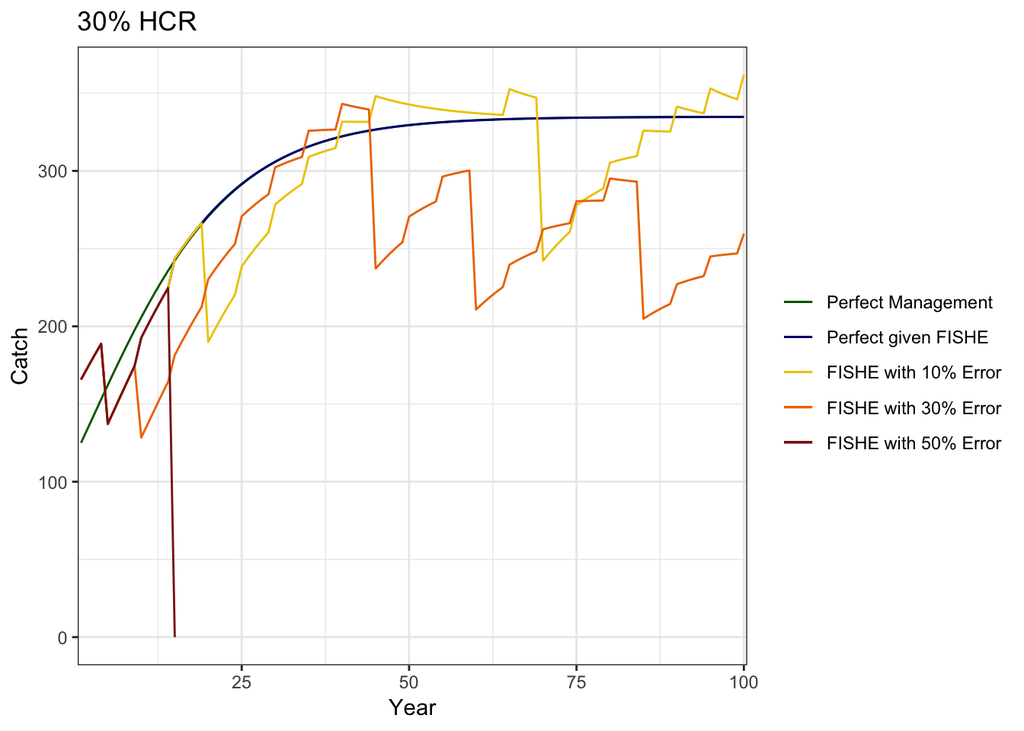

## 35% Reduction

Subset for b0 = 1500 and r = 0.1; perfect management won’t change so just need to subset for perfect given FISHE and the error tests.

Graph biomass and catch over time:

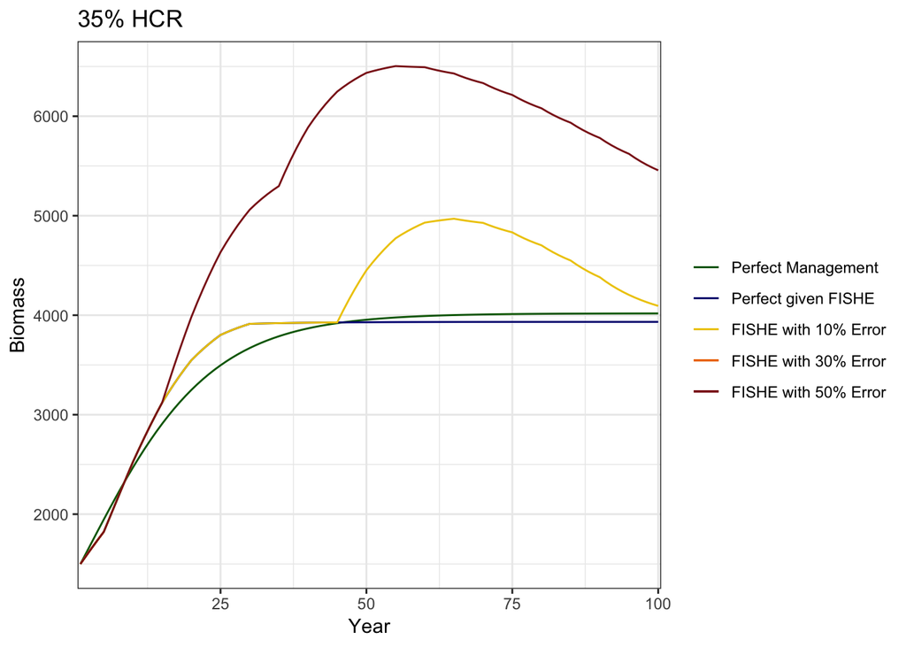

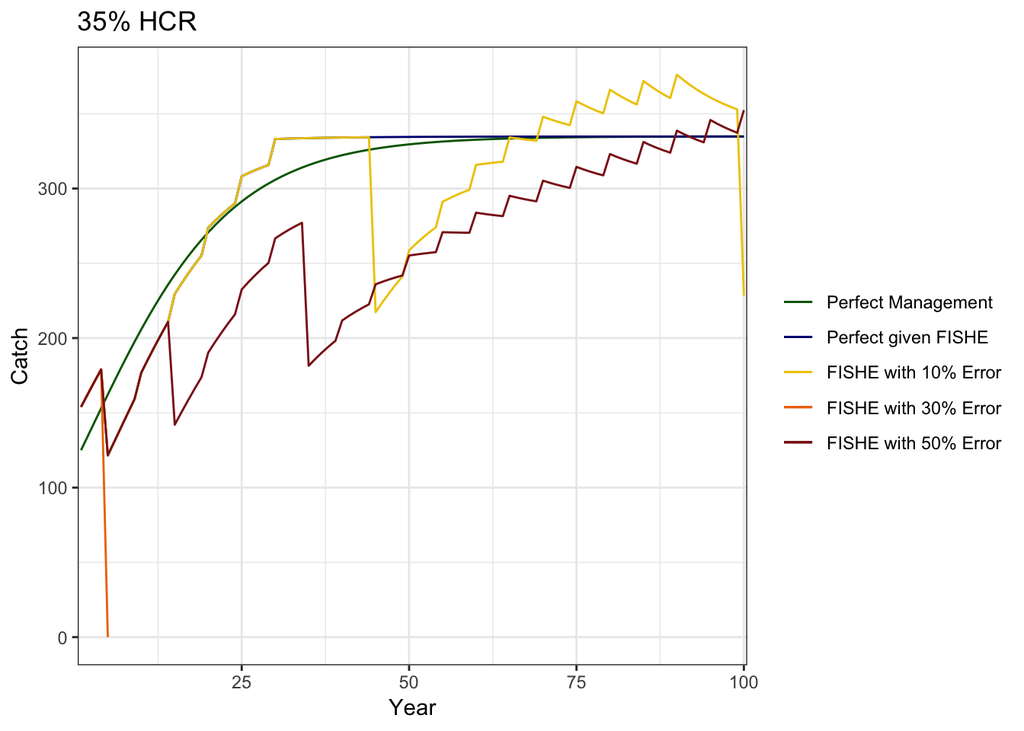

## 40% Reduction

Subset for b0 = 1500 and r = 0.1; perfect management won’t change so just need to subset for perfect given FISHE and the error tests.

Graph biomass and catch over time:

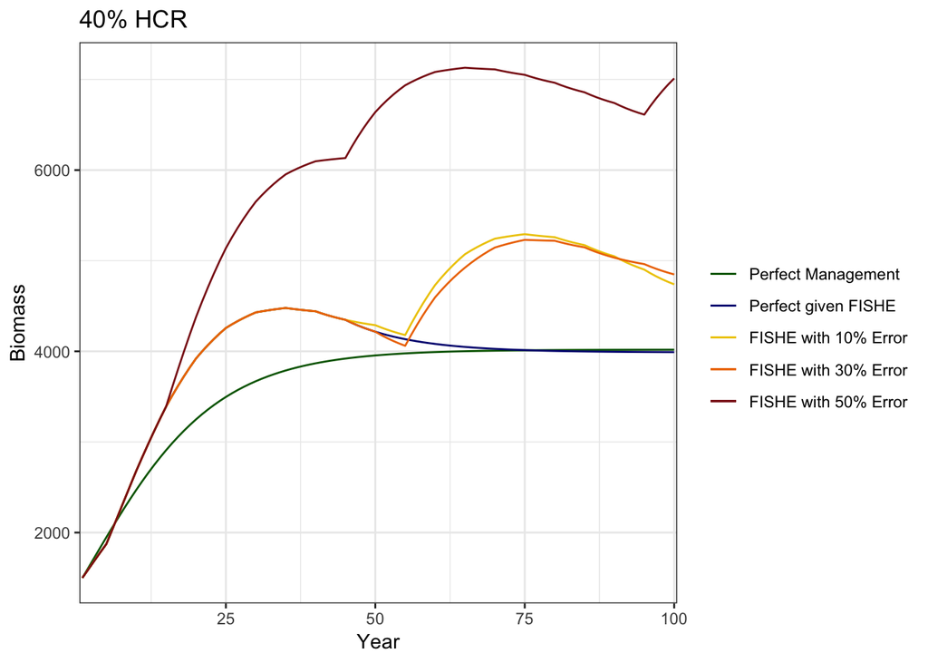

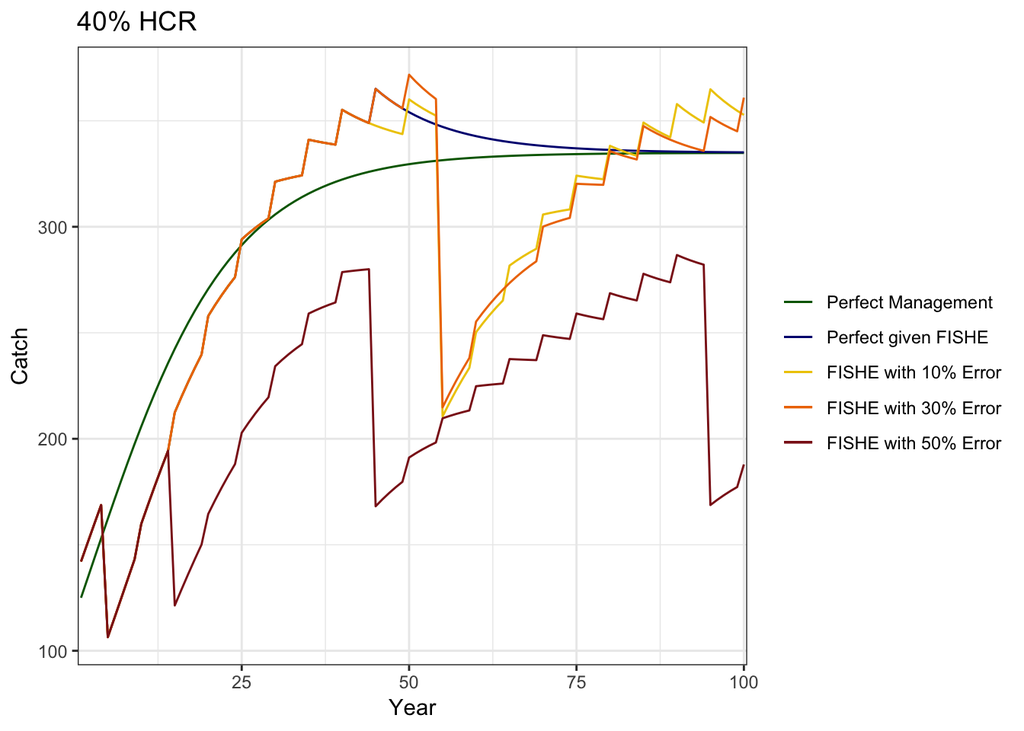

## 45% Reduction

Subset for b0 = 1500 and r = 0.1; perfect management won’t change so just need to subset for perfect given FISHE and the error tests.

Graph biomass and catch over time:

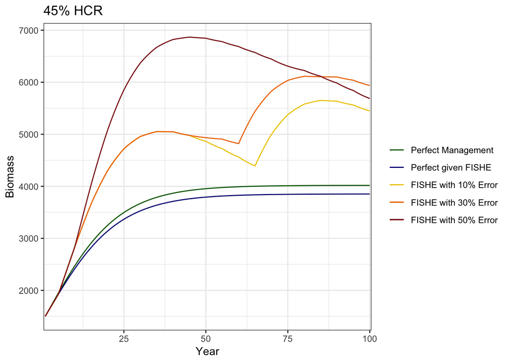

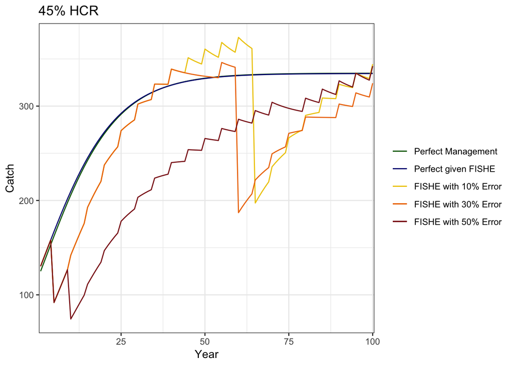

## 50% Reduction

Subset for b0 = 1500 and r = 0.1; perfect management won’t change so just need to subset for perfect given FISHE and the error tests.

Graph biomass and catch over time:

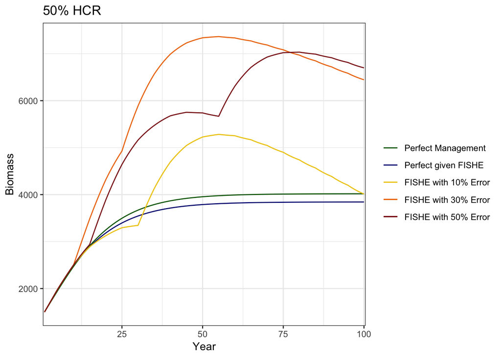

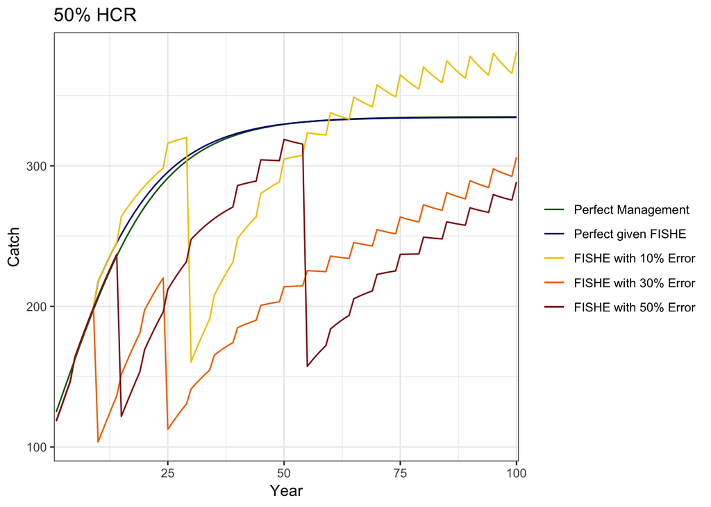

## HCR Table

Make a table with different errors as the rows and the number of simulations that went over the limit (with error) at each of the different HCRs

Create the tables:

| Error | 30% Reduction Yes | 30% Reduction No | 25% Reduction Yes | 25% Reduction No | 20% Reduction Yes | 20% Reduction No | 15% Reduction Yes | 15% Reduction No | 10% Reduction Yes | 10% Reduction No |
| --- | --- | --- | --- | --- | --- | --- | --- | --- | --- | --- |
| 0.1 | 0 | 24 | 0 | 24 | 0 | 24 | 0 | 24 | 1 | 23 |
| 0.3 | 1 | 23 | 3 | 21 | 3 | 21 | 5 | 19 | 8 | 16 |
| 0.5 | 11 | 13 | 12 | 12 | 13 | 11 | 17 | 7 | 16 | 8 |

| Error | 50% Reduction Yes | 50% Reduction No | 45% Reduction Yes | 45% Reduction No | 40% Reduction Yes | 40% Reduction No | 35% Reduction Yes | 35% Reduction No |
| --- | --- | --- | --- | --- | --- | --- | --- | --- |
| 0.1 | 0 | 24 | 0 | 24 | 0 | 24 | 0 | 24 |
| 0.3 | 0 | 24 | 1 | 23 | 4 | 20 | 1 | 23 |
| 0.5 | 10 | 14 | 6 | 18 | 8 | 16 | 9 | 15 |

## HCR Table 2

Re-ran the model to compare outcomes since error is drawn randomly

Create the tables:

| Error | 30% Reduction Yes | 30% Reduction No | 25% Reduction Yes | 25% Reduction No | 20% Reduction Yes | 20% Reduction No | 15% Reduction Yes | 15% Reduction No | 10% Reduction Yes | 10% Reduction No |
| --- | --- | --- | --- | --- | --- | --- | --- | --- | --- | --- |
| 0.1 | 0 | 24 | 0 | 24 | 0 | 24 | 0 | 24 | 0 | 24 |
| 0.3 | 0 | 24 | 4 | 20 | 0 | 24 | 5 | 19 | 5 | 19 |
| 0.5 | 8 | 16 | 10 | 14 | 11 | 13 | 13 | 11 | 18 | 6 |

| Error | 50% Reduction Yes | 50% Reduction No | 45% Reduction Yes | 45% Reduction No | 40% Reduction Yes | 40% Reduction No | 35% Reduction Yes | 35% Reduction No |
| --- | --- | --- | --- | --- | --- | --- | --- | --- |
| 0.1 | 0 | 24 | 0 | 24 | 0 | 24 | 0 | 24 |
| 0.3 | 0 | 24 | 1 | 23 | 2 | 22 | 2 | 22 |
| 0.5 | 6 | 18 | 6 | 18 | 10 | 14 | 9 | 15 |

Going to use the 30% reduction